# Multi-level Graphs for Railway Timetables

*Settembre 2018*

## Introduction

The **multi-level graph structure** is a *hierarchical decomposition* tecnique which allows to speed-up shortest path problems on very big graphs.

The idea of this algorithm is to create a *shortest-path distance preserving* graph smaller than the original one, on which one can efficiently solve computationally expensive problems.

After a formal description of the method, we'll look at the improvements in the  
performance of *Dijkstra's algorithm* applied to **railway timetable information graphs**.

## Multi-level Graphs

Let \(G = (V,E)\) be a weighted directed graph with non-negative weights.

We want to extend both the number of edges and the number of *levels* of this graph, is such a way that **single-pair shortest path** algorithms can be applied efficiently on a smaller subgraph.

We start from a nested sequence of subsets of nodes \[ V \supset S_1 \supset \dots \supset S_l \] which will be used to define the associated **multi-level graph** \(\mathcal{M}(G;S_1,\dots,S_l)\) and its \(l+1\) levels.

## Multi-level Graphs

### Levels

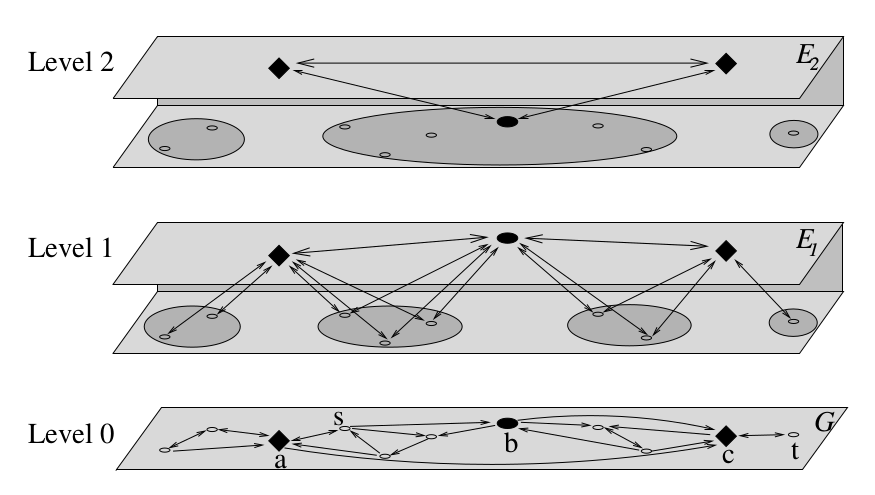

Each level is a graph contaning all the nodes from \(S_i\) and three possible kinds of edges:

- *level edges* \(E_i\subseteq S_i \times S_i\);
- *upward edges* \(U_i \subseteq (S_{i-1}\setminus S_i) \times S_i\);
- *downward edges* \(D_i \subseteq S_i \times (S_{i-1}\setminus S_i)\).

The **i-th level** of \(\mathcal{M}(G;S_1,\dots,S_l)\) is defined as the triple \(L_i := (E_i, U_i, D_i)\).

Level \(0\) is set to \(L_0 := (E, \emptyset, \emptyset)\).

## Multi-level Graphs

### Construction

The costruction of the levels is iterative:

- At the *i-th step* for each node \(u\in S_{i-1}\) consider a shortest-path tree \(T_u\) in the graph \((S_{i-1},E_{i-1})\).
- Level, upward and downward edges in the new level \(L_i\) are chosen with the following condition:

Edge \((u,v)\) belongs to \(L_i\) if and only if no internal  
vertex of the shortest path \(u-v\) in \(L_u\) belongs to \(S_i\).

Notice that, since the shortest paths are not generally unique, this construction is not uniquely determined.

Now we define the **multi-level graph** \[ \mathcal{M}(G;S_1,\dots,S_l) := \Big(V, E \cup \bigcup_{i=1,\dots,l}(E_i \cup U_i \cup D_i) \Big). \]

## Multi-level Graphs

### Connected components

Let's now consider the subgraphs of \(G\) induced by the nodes in \(V\setminus S_i\).

We'll use the following notation for each subgraph:

- \(\mathcal{C}_i\) is the set of its connected components;
- \(C_i^v\) is the connected component in \(\mathcal{C}_i\) containing \(v\in V\setminus S_i\);
- \(v\in S_i\) is said to be *adjacent* to a component \(C\in\mathcal{C}_i\) if there is at least one edge connecting them.

## Multi-level Graphs

### Connected components

Let's now consider the subgraphs of \(G\) induced by the nodes in \(V\setminus S_i\).

Edges \(E_i\) represent the shortest paths *between vertices of \(S_i\) passing through a connected component*.

Edges \(U_i\) represent the shortest paths *from a vertex inside a connected component to all vertices of \(S_i\) adjacent to that component*.

Edges \(D_i\) represent the shortest paths *from the adjacent vertices of a component to a vertex of that component*.

## Multi-level Graphs

### Component Tree

Now we define the structure in which we are going to search for the shortest-distance preserving paths between nodes of \(G\), the so called **component tree**:

- *Nodes* are made by the components in \(\mathcal{C}_1\cup\dots\cup\mathcal{C}_l\), a root \(C_{l+1}\) and a leaf \(C_0^v\) for each node \(v\in V\);
- *Edges* are built as follows:
  - the parent of a leaf \(C_0^v\) is \(C_{l+1}\) if the largest index such as \(v\in S_i\) is \(i=l\), and \(C_{i+1}^v\in \mathcal{C}_{i+1}\) otherwise;
  - the parent of any other component \(C_i\in \mathcal{C}_i\) is the component \(C_{i+1}\in\mathcal{C}_{i+1}\) such that \(V(C_i)\subseteq V(C_{i+1})\).

## Multi-level Graphs

### Component Tree

Given two nodes \(s,t\in V\), we define the subgraph \(\mathcal{M}_{st}\subseteq\mathcal{M}\) induced by the edge set \[ \begin{align} E_{st} := E_{L-1} &\cup \bigcup_{i=k,\dots,L-1} \{(u,v)\in U_i | u \in Adj(C_{i-1}^s), v\in Adj(C_i^s) \}\\ &\cup \bigcup_{i=k',\dots,L-1} \{(u,v)\in D_i | u \in Adj(C_{i}^t), v\in Adj(C_{i-1}^t) \} \end{align} \] where \(L\) is the smallest index such that \(C_L^s=C_L^t\), while \(k\) and \(k'\) are the indexes corresponding to leaves' parent nodes.

**Lemma.** The length of the shortest s-t path is the same in the graphs \(G\) and \(\mathcal{M}_{st}\).

## Graph representation of Timetable Information

### Adapting the Multi-level Graph approach

Our goal is to provide a train connection with **earliest arrival time**.

We assume that the timetable is periodic with period of one day and reduce the problem to a graph *shortest-path* problem.

## Graph representation of Timetable Information

### Adapting the Multi-level Graph approach

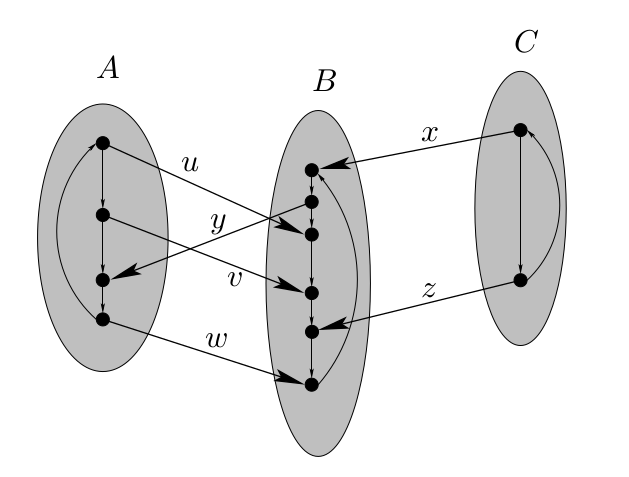

A **Train Graph (\(TG\))** contains a vertex for every arrival and departure time and two possible edges:

- *stay edges*, inside a single station, are ordered according to arrival and departure in the time period and weighted with the duration of the stay;
- *travel edges*, between different stations, are also connected according to timing, but weighted with the duration of the travel.

Notice that the problem inside this graph is reduced to a **single-source some-target** shortest path problem, due to the set of vertices belonging to a single station.

## Graph representation of Timetable Information

### Adapting the Multi-level Graph approach

We need an additional structure.

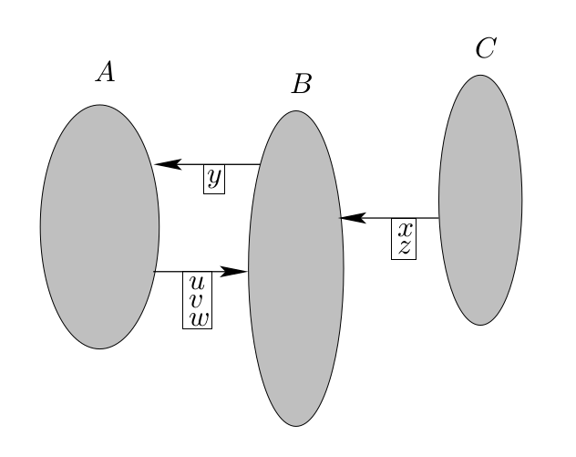

A **Station Graph (\(SG\))** contains a vertex for each station and is unweighted.

Two stations are connected if and only if there is at least a travel edge between them in the train graph.

## Graph representation of Timetable Information

### Adapting the Multi-level Graph approach

Now we need to define a modified version of the multi-level graph \(\mathcal{M}(TG)\).

- There are two *nested sequences of sets*:
  - \(l\) sets of stations \(V(SG) \supset \Sigma_1 \supset \dots \supset \Sigma_l\);
  - \(l\) sets of timing nodes \(V(TG) \supset S_1 \supset \dots \supset S_l\).
- The *component tree* is computed only inside the station graph.
  - The is one leaf \(C^R\) for each station \(R\);
  - \(Adj(C^R) = T(R)\) is the set of all arrivals and departures belonging to the station \(R\).
- A vertex \(v\in TG\) is said to be *adjacent* to a component \(C\) of \(SG\) if \(v\) and \(C\) are connected by at least one edge in the station graph.

**Proposition.** For each departure node \(v\) in \(TG\) belonging to the station \(s\) in \(SG\), the shortest-path from \(v\) to one of the nodes in \(s\) is the same in the graphs \(TG\) and \(\mathcal{M}_{st}(TG)\).

## Results

The experiments conducted in the reference article *"Using Multi-level Graphs for Timetable Information in Railway Systems", Frank Schulz, Dorothea Wagner and Christos Zaroliagis, Springer-Verlag Berlin, 2002* involve train data of German railways consisting of: 6960 stations, 931746 vertices and 1397619 edges.

Their goal is to compare the performances for the computation of *Dijkstra's algorithm* in the train graph against the subgraph of \(\mathcal{M}\).

Let **CPU-speedup** be the ratio between CPU time needed in \(TG\) and in \(\mathcal{M}\) (notice that this also measures the computation of \(\mathcal{M}\)) and **space consumption** be the relative size of \(\mathcal{M}\) in terms of number of edges.

Then, the improvement in performances is computed as \[ efficency = \frac{\text{CPU speedup}}{\text{space consumption}}= \frac{time(TG)/time(\mathcal{M})}{size(\mathcal{M})/size(TG)}. \]

## Results

### Selection Criteria in 2-level graphs

Consider three different sequences of nested sets \(\Sigma_1^k \supset \dots \supset \Sigma_{10}^k\) for \(k=1,2,3\).

- The first level \(\Sigma_1^k\) is the same for each \(k\). It contains all the \(1974\) stations in \(SG\) with degree greater than \(2\);
- The other levels have equally spaced sizes in the range from \(1974\) to \(50\) but using different selection methods for the stations.

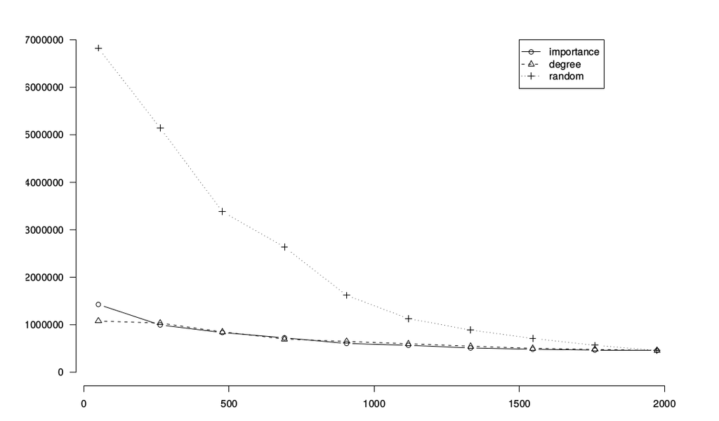

This plot shows the **number of edges** (size of the graph) of the first level in the 2-level graph \(\mathcal{M(\Sigma_i^k)}\) based on the different *selection criteria*:

- the **importance** assigned to each station in the data table;
- the highest **degree**;
- **random** stations (too many edges!).

## Results

### Speedup and efficency in 2-level graphs

We now focus on the performances of the *importance*-based sequence.

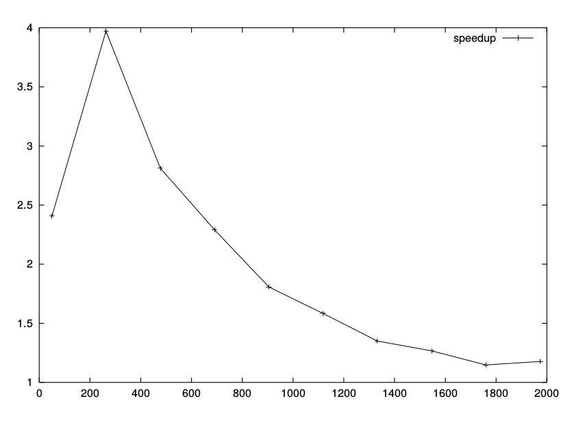

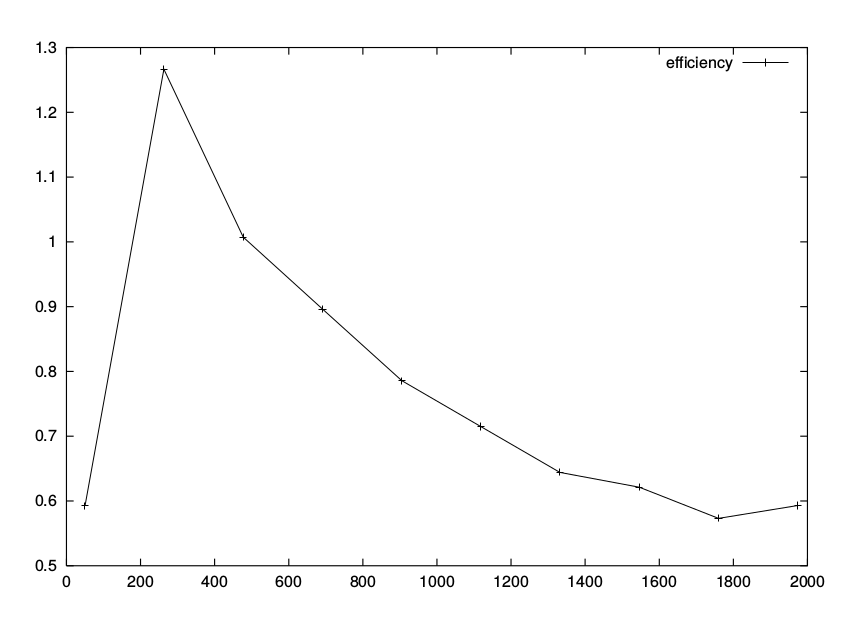

Both speedup and efficency increase with a decreasing number of stations, but we can notice a sudden drop from \(\Sigma_9\) to \(\Sigma_{10}\).

This is because the number of stations has to be *small enough to reduce the number of edges but big enough to avoid computing the shortest paths in level 0*.

## Results

### Multiple levels

In the case of an \(l\)-level graph we follow an iterative approach.

Given a \(l-1\)-level graph and its sequence \(\Sigma_1\supset \dots\supset \Sigma_{l-2}\) we choose the best \(\Sigma_{l-2}\subset\Sigma_{l-1}\) in terms of efficiency.

If there are no more smaller sets available from the originally constructed sequence, we generate \(l\) new equally spaced nested subsets of \(\Sigma_{l-1}\) and choose the best one between them.

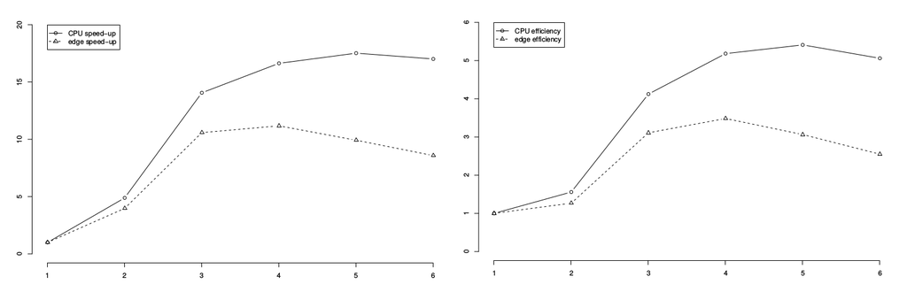

## Conclusions

We explored an interesting graph decomposition approach for search algorithms, focusing on the performances of *Dijkstra's algorithm*.

*Random selection* of nodes turned out to be the worst possible choice of sets.